# Système de Recommandation

## Partie 0 : Réglages

```python
%load_ext autoreload
%autoreload 2
```

```
The autoreload extension is already loaded. To reload it, use:
  %reload_ext autoreload
```

```python
import numpy as np
import scipy as sp
import random
import matplotlib.pyplot as plt

#Fonctions permettant de simuler le jeu
from exp import games, cumulative_regret, cumulative_reward, logarithmic_indices

#Fonctions permettant de simuler le joueur
from player import Oracle, EpsilonNGreedy, ThompsonSamplingBernoulli, UCB1

from Optimize import OptimizeEN, OptimizeUCB1, OptimizeAll
```

```python
from arm import MyBeta, Bernoulli

environment = [MyBeta(mean=0.79), MyBeta(mean=0.17), MyBeta(mean=0.51), MyBeta(mean=0.45), MyBeta(mean=0.77), MyBeta(mean=0.38), MyBeta(mean=0.43), MyBeta(mean=0.43), MyBeta(mean=0.5), MyBeta(mean=0.41)]
random.shuffle(environment)

environment2 = [Bernoulli(p = 0.1),Bernoulli(p = 0.2),Bernoulli(p = 0.3),Bernoulli(p = 0.4),Bernoulli(p = 0.5),Bernoulli(p = 0.6),Bernoulli(p = 0.7),Bernoulli(p = 0.8),Bernoulli(p = 0.9)]
random.shuffle(environment2)

n_iter = 1000
n_iter2 = 50000
n_games = 5
n_games2 = 250
```

## Partie 1 : Optimisation des algorithmes ; Loi Beta

### 1.1 : Optimisation de Epsilon-N-Greedy (EN)

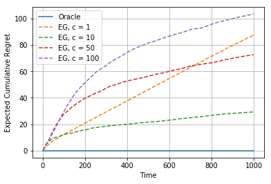

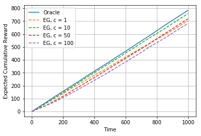

```
'End'
```

```python
OptimizeEN(environment, n_iter, n_games)
```

On remarque que l'EN est meilleur (plus proche du joueur Oracle) dans le cas où la constance c vaut 10. Cette constatation se voit d'autant plus sur le graphique du regret cumulé. Ainsi la valeur de c = 10 semble donner le meilleur joueur de EN. Nous allons, dans la suite de cette partie, vérifier si la constante optimale est indépendante du nombre de coups par partie et du nombre de parties jouées.

#### Modification du nmbre de coups par partie.

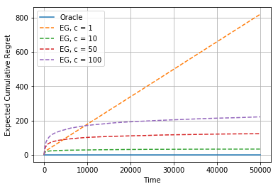

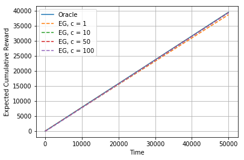

```
'End'
```

```python
OptimizeEN(environment, n_iter2, n_games)
```

#### Modification du nombre de parties

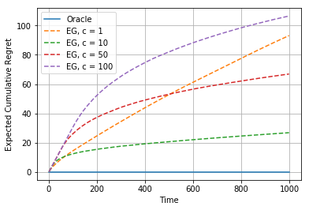

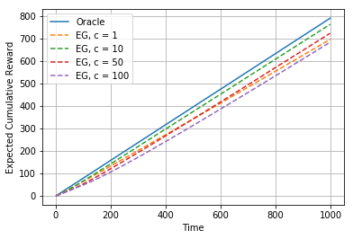

```
'End'
```

```python
OptimizeEN(environment, n_iter, n_games2)
```

Même en changeant le nombre de parties jouées, le joueur optimal reste le joueur c = 10. Nous allons donc prendre cette valeur pour comparer l'EN avec les autres joueurs.

### 1.2 : Optimisation de l'UCB1

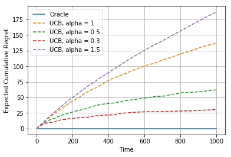

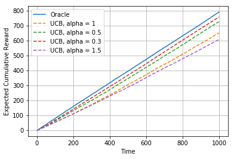

```
'End'
```

```python
OptimizeUCB1(environment, n_iter, n_games)
```

Plus on diminue le coefficient alpha et plus notre joueur est performant ! Nous allons vérifier la robustesse de cette assertion sous le changement des mêmes paramètres que pour l'EN.

#### Modification du nombre de coups par partie

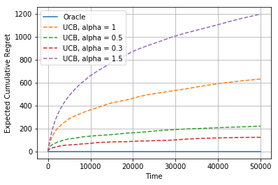

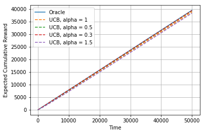

```
'End'
```

```python
OptimizeUCB1(environment, n_iter2, n_games)
```

Indépendance de alpha par rapport au nombre de coups par partie.

#### Modification du nombre de parties

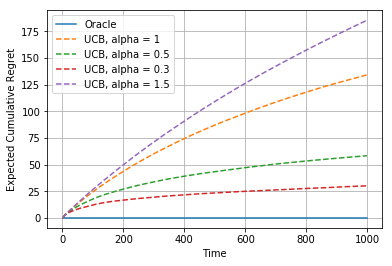

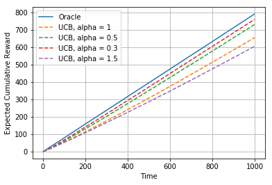

```
'End'
```

```python
OptimizeUCB1(environment, n_iter, n_games2)
```

Indépendance de alpha par rapport aux nombre des parties. Ainsi plus alpha diminue et plus notre joueur sera performant. Nous prendrons néanmoins une valeur de alpha de 0.5 pour la suite du TP.

## Partie 2 : Comparaison des différents algorithmes

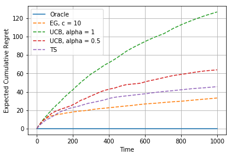

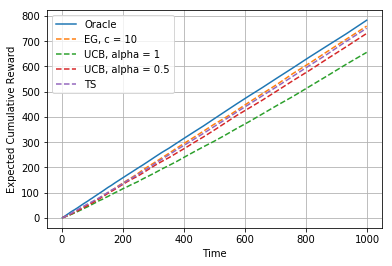

```
'End'
```

```python
OptimizeAll(environment, n_iter, n_games)
```

Le joueur EN gagne la partie ! Avec son paramètre c = 10, il est le meilleur joueur présent dans nos parties. Même si le paramètrage de nos joueurs (UCB, EN, Oracle) est indépendant du nombre de parties et du nombre de coups, nous allons vérifier que le résultat le soit aussi (car le joueur de TS n'a pas été étudié encore).

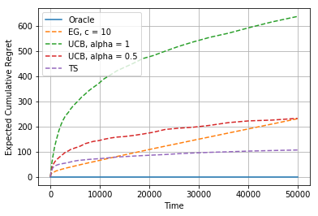

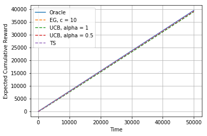

```
'End'
```

```python
OptimizeAll(environment, n_iter2, n_games)
```

L'algorithme de TS est plus performant que les autres si on augmente le nombre de coups par partie.

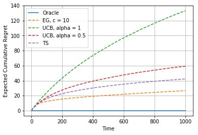

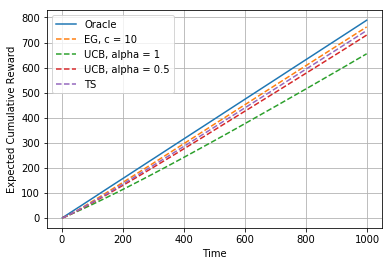

```
'End'
```

```python
OptimizeAll(environment, n_iter, n_games2)
```

En augmentant uniquement le nombre de partie, le joueur EN est le meilleur joueur.

On a donc un joueur optimal dépendant du paramétrage du jeu. Si une partie est longue (comme pour le cas numéro 2) alors le joueur de TS est meilleur. Sinon L'EN est optimal.

## Partie 3 : Optimisation des algorithmes ; Loi de Bernoulli

Dans cette partie nous allons refaire exactement les mêmes joueurs, optimiser de façon identique mais nous ne jouerons plus selon une loi Beta, mais selon une loi de Bernoulli.

### 3.1 : Optimisation de Epsilon-N-Greedy (EN)

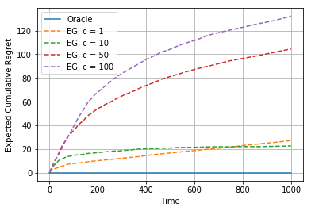

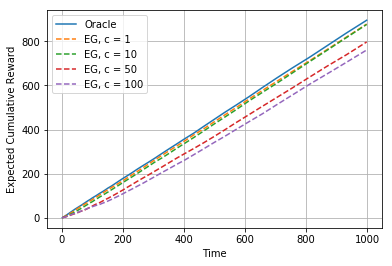

```
'End'
```

```python
OptimizeEN(environment2, n_iter, n_games)
```

#### Modification du nombre de coups par partie

##### Sortie 1

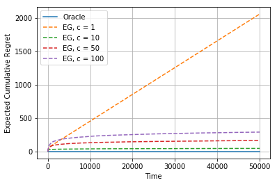

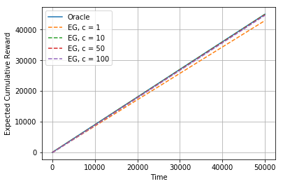

```
'End'
```

```python
OptimizeEN(environment2, n_iter2, n_games)
```

##### Sortie 2

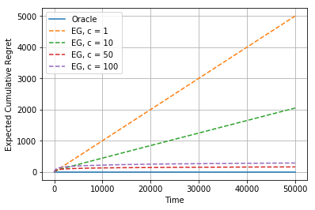

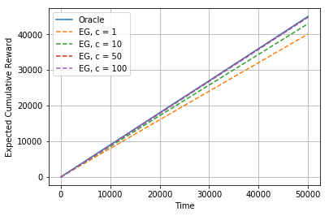

```
'End'
```

```python
OptimizeEN(environment2, n_iter2, n_games)
```

#### Modification du nombre de parties

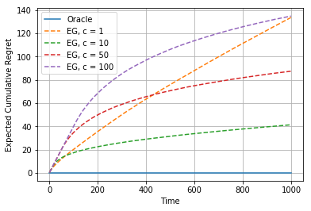

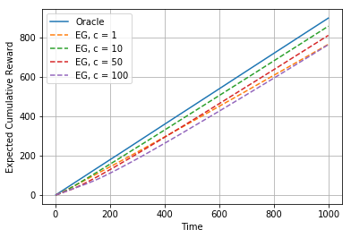

```
'End'
```

```python
OptimizeEN(environment2, n_iter, n_games2)
```

Selon les règles du jeu Bernoulli, le joueur avec c = 10 est encore le meilleur, peu importe le nombre de parties. Une nuance s'ajoute cependant, et est imagée par les Sorties 1 et 2. Le résultat est assez instable en changeant le nombre de coups par parties. Le joueur c = 10 n'est pas forcément le meilleur pour n_iter = 50000. Le joueur c = 50 est beaucoup plus régulier et semble donc être un meilleur choix si la partie possède 50000 coups.

Cette constation est sûrement la conséquence du fait que la loi de Bernoulli n'est pas une loi continue. Ainsi la binarité du choix augmente les écarts entre les résultats d'un même joueur.

### 3.2 : Optimisation de l'UCB1

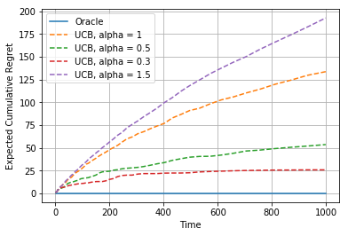

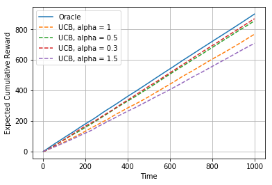

```
'End'
```

```python
OptimizeUCB1(environment2, n_iter, n_games)
```

#### Modification du nombre de coups par partie

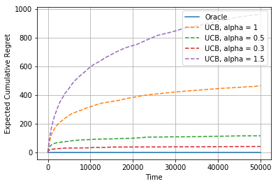

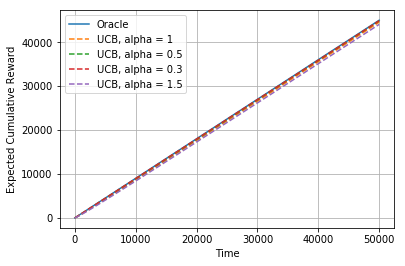

```
'End'
```

```python
OptimizeUCB1(environment2, n_iter2, n_games)
```

#### Modification du nombre de parties

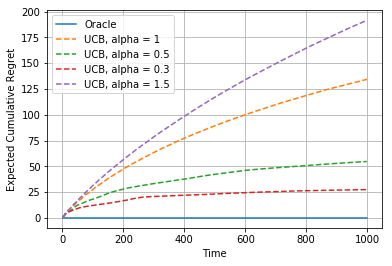

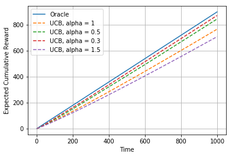

```
'End'
```

```python
OptimizeUCB1(environment2, n_iter, n_games2)
```

On constate que le meilleur joueur est aussi le joueur avec le alpha le plus petit. Je vais donc faire les mêmes choix dans la définiton de mon alpha.

## Partie 4 : Comparaison des différents algorithmes

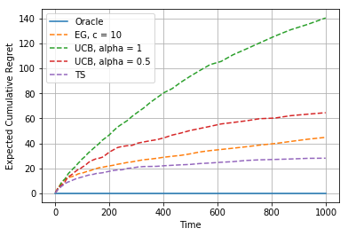

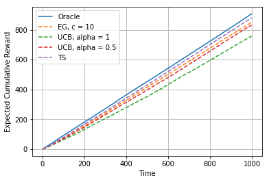

```
'End'
```

```python
OptimizeAll(environment2, n_iter, n_games)
```

Dans le cas du jeu de Bernoulli, le joueur TS est meilleur que les autres. En relançant plusieurs fois cette même fonction, on remarque qu'il peut arriver que le joueur EN avec c = 10 soit légèrement meilleur. Cependant TS est plus optimal en général.

#### Modification du nombre de coups par partie

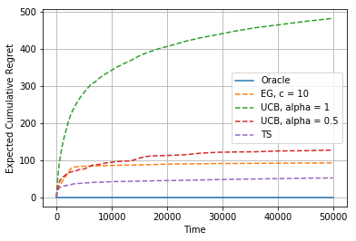

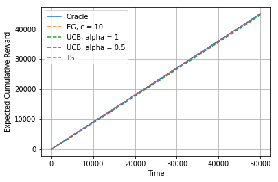

```
'End'
```

```python
OptimizeAll(environment2, n_iter2, n_games)
```

TS reste le meilleur joueur.

#### Modification du nombre de parties

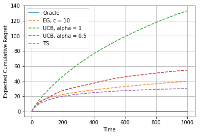

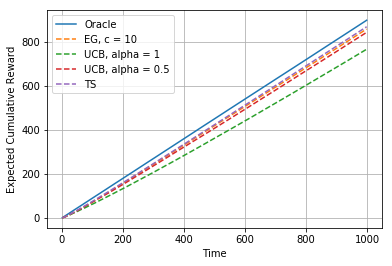

```
'End'
```

```python
OptimizeAll(environment2, n_iter, n_games2)
```

TS est encore une fois le meileur joueur. Ainsi le joueur suivant le principe TS gère mieux le caractère "tranché" de la loi de bernoulli et ceux peut importe le paramètrage.